# Bike rental prediction

The aim of this work is to predict the total amount of rented bike. The predictors are: ** instant: record index ** dteday : date ** season: season (1:winter, 2:spring, 3:summer, 4:fall) ** year: (0: 2011, 1:2012) ** month: month ( 1 to 12) ** holiday: weather day is holiday or not (extracted from [Web Link]) ** weekdaynum: day of the week ** is_workingday: if day is neither weekend nor holiday is 1, otherwise is 0. ** weathersituation: 1: Clear, Few clouds, Partly cloudy, Partly cloudy 2: Mist + Cloudy, Mist + Broken clouds, Mist + Few clouds, Mist 3: Light Snow, Light Rain + Thunderstorm + Scattered clouds, Light Rain + Scattered clouds 4: Heavy Rain + Ice Pallets + Thunderstorm + Mist, Snow + Fog ** atemp_normalized: Normalized feeling temperature in Celsius. The values are derived via (t-tmin)/(tmax-tmin), tmin=-16, t_max=+50 (only in hourly scale) ** humidity_normalized: Normalized humidity. The values are divided to 100 (max) ** windspeed_normalized: Normalized wind speed. The values are divided to 67 (max)

```r
train <- read.csv(file.choose())
rownames(train) <- train$ID
train <- train[,2:13]
train2 <- train[,2:12]
```

ID variables has been sected as row names and the date has been used with the only purpose to represent the outcome graphically. So, the final amount of variables used was 11.

```r
str(train)
```

```
## 'data.frame':    599 obs. of  12 variables:
##  $ dteday              : chr  "01-01-2011" "02-01-2011" "03-01-2011" "04-01-2011" ...
##  $ season              : int  1 1 1 1 1 1 1 1 1 1 ...
##  $ year                : int  0 0 0 0 0 0 0 0 0 0 ...
##  $ Month               : int  1 1 1 1 1 1 1 1 1 1 ...
##  $ is_holiday          : int  0 0 0 0 0 0 0 0 0 0 ...
##  $ weekdaynum          : int  6 0 1 2 3 4 5 6 0 1 ...
##  $ is_workingday       : int  0 0 1 1 1 1 1 0 0 1 ...
##  $ weathersituation    : int  2 2 1 1 1 1 2 2 1 1 ...
##  $ atemp_normalized    : num  0.364 0.354 0.189 0.212 0.229 ...
##  $ humidity_normalized : num  0.806 0.696 0.437 0.59 0.437 ...
##  $ windspeed_normalized: num  0.16 0.249 0.248 0.16 0.187 ...
##  $ total_rental        : int  985 801 1349 1562 1600 1606 1510 959 822 1321 ...
```

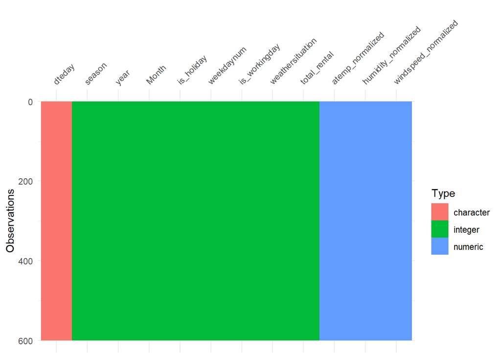

```r
library(visdat)
vis_dat(train)
```

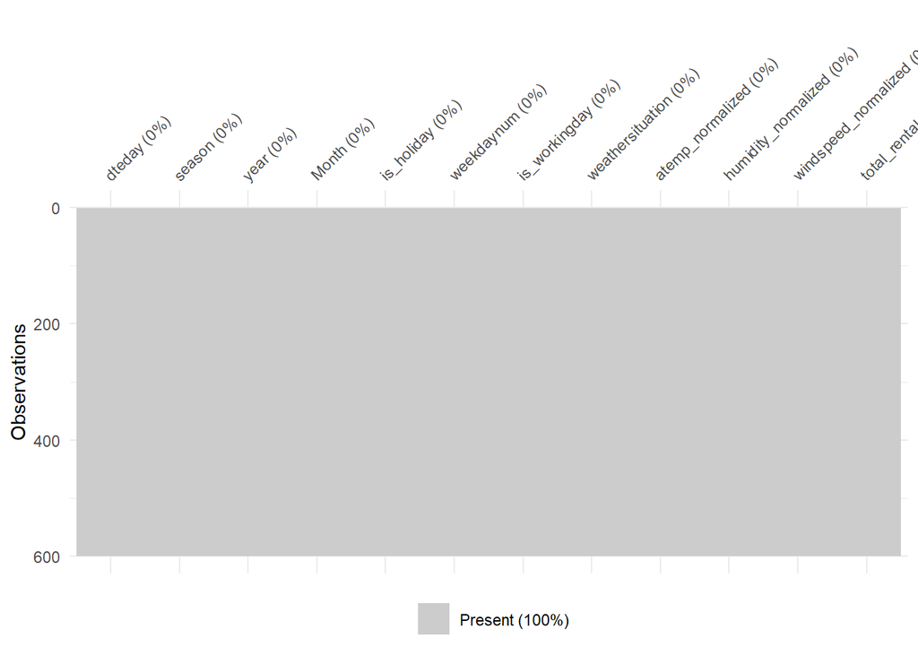

```r
vis_miss(train)
```

```r
library(skimr)
skim(train)
```

Data summary

| Name | train |
| --- | --- |
| Number of rows | 599 |
| Number of columns | 12 |
| _______________________ |  |
| Column type frequency: |  |
| character | 1 |
| numeric | 11 |
| ________________________ |  |
| Group variables | None |

**Variable type: character**

| skim_variable | n_missing | complete_rate | min | max | empty | n_unique | whitespace |
| --- | --- | --- | --- | --- | --- | --- | --- |
| dteday | 0 | 1 | 10 | 10 | 0 | 599 | 0 |

**Variable type: numeric**

| skim_variable | n_missing | complete_rate | mean | sd | p0 | p25 | p50 | p75 | p100 | hist |
| --- | --- | --- | --- | --- | --- | --- | --- | --- | --- | --- |
| season | 0 | 1 | 2.27 | 1.03 | 1.00 | 1.00 | 2.00 | 3.00 | 4.00 | ▇▇▁▇▃ |
| year | 0 | 1 | 0.39 | 0.49 | 0.00 | 0.00 | 0.00 | 1.00 | 1.00 | ▇▁▁▁▅ |
| Month | 0 | 1 | 5.68 | 3.21 | 1.00 | 3.00 | 5.00 | 8.00 | 12.00 | ▇▆▆▃▅ |
| is_holiday | 0 | 1 | 0.03 | 0.16 | 0.00 | 0.00 | 0.00 | 0.00 | 1.00 | ▇▁▁▁▁ |
| weekdaynum | 0 | 1 | 2.99 | 2.00 | 0.00 | 1.00 | 3.00 | 5.00 | 6.00 | ▇▃▃▃▇ |
| is_workingday | 0 | 1 | 0.69 | 0.46 | 0.00 | 0.00 | 1.00 | 1.00 | 1.00 | ▃▁▁▁▇ |
| weathersituation | 0 | 1 | 1.39 | 0.55 | 1.00 | 1.00 | 1.00 | 2.00 | 3.00 | ▇▁▅▁▁ |
| atemp_normalized | 0 | 1 | 0.48 | 0.17 | 0.08 | 0.34 | 0.50 | 0.62 | 0.84 | ▂▆▆▇▂ |
| humidity_normalized | 0 | 1 | 0.62 | 0.15 | 0.00 | 0.51 | 0.62 | 0.73 | 0.97 | ▁▁▆▇▂ |
| windspeed_normalized | 0 | 1 | 0.19 | 0.08 | 0.02 | 0.14 | 0.18 | 0.23 | 0.51 | ▂▇▅▁▁ |
| total_rental | 0 | 1 | 4220.60 | 1819.67 | 431.00 | 2904.00 | 4294.00 | 5353.50 | 8362.00 | ▃▅▇▃▂ |

```
## 1 columns ignored with more than 50 categories.
## dteday: 599 categories
```

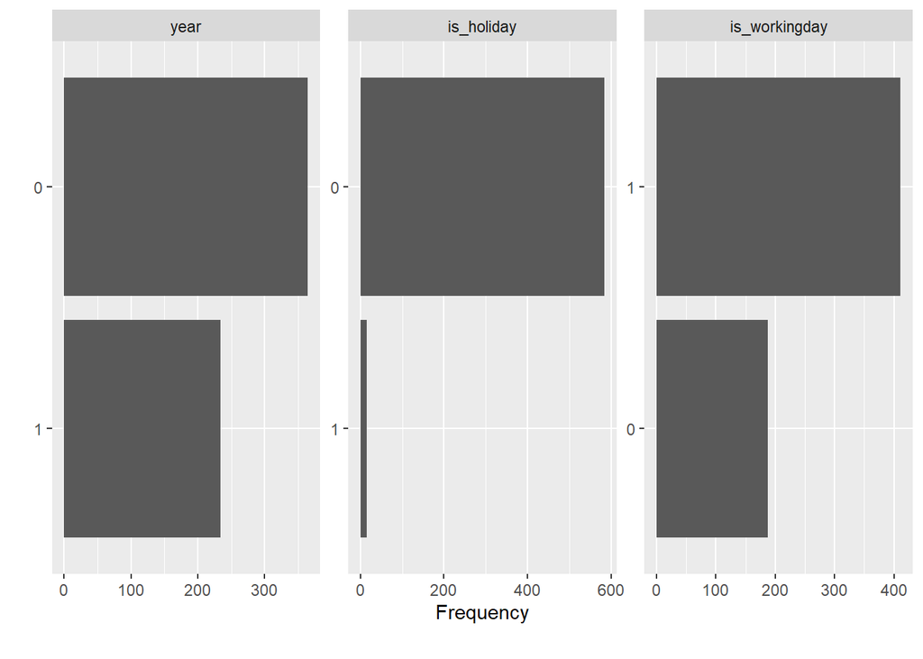

```r
library(DataExplorer)
plot_bar(train)
```

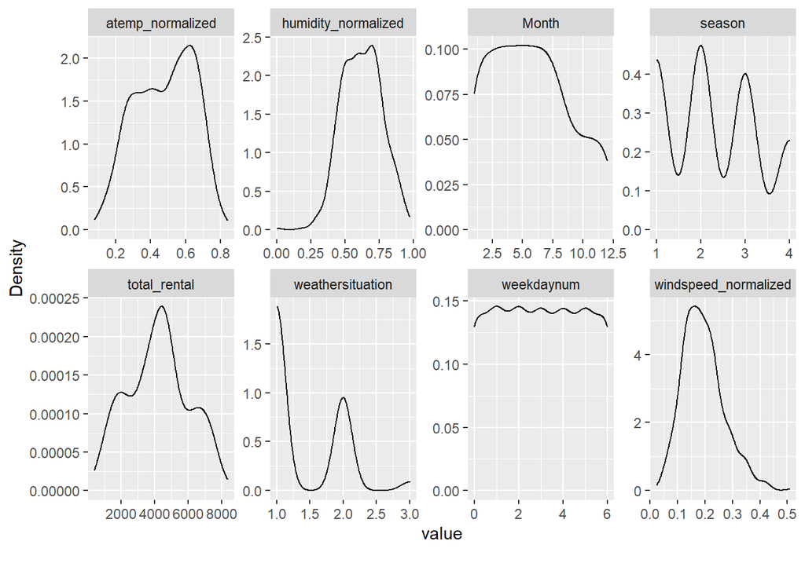

```r
plot_density(train)
```

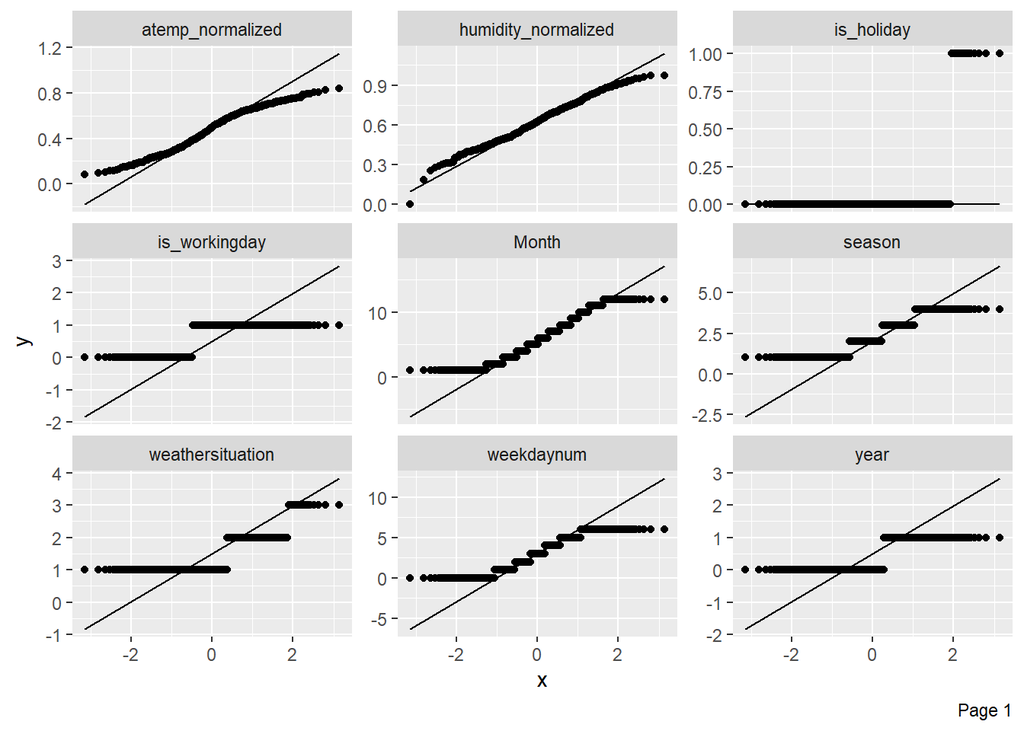

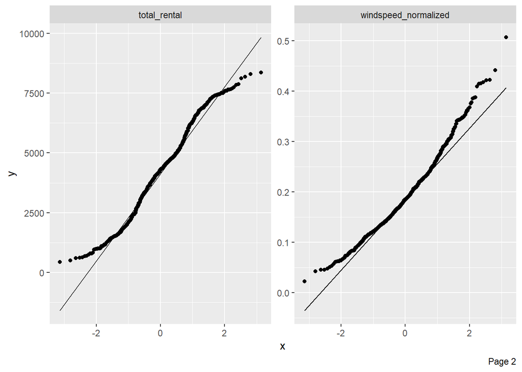

```r
plot_qq(train)
```

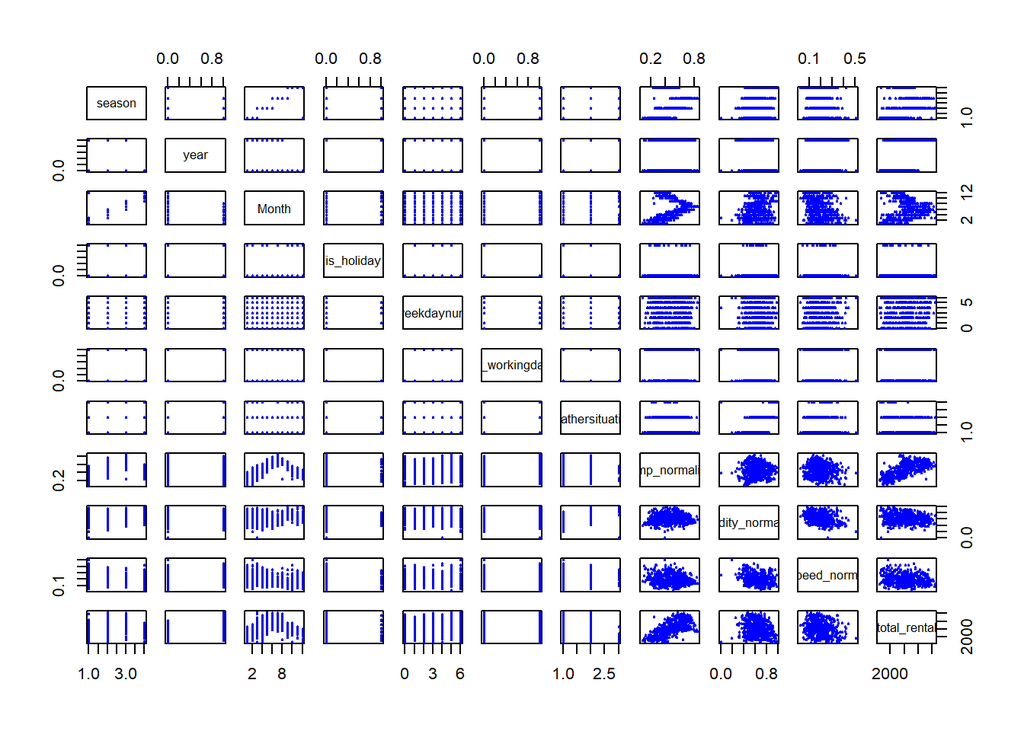

```r
pairs(train2, pch=20, cex=0.4, col="blue")
```

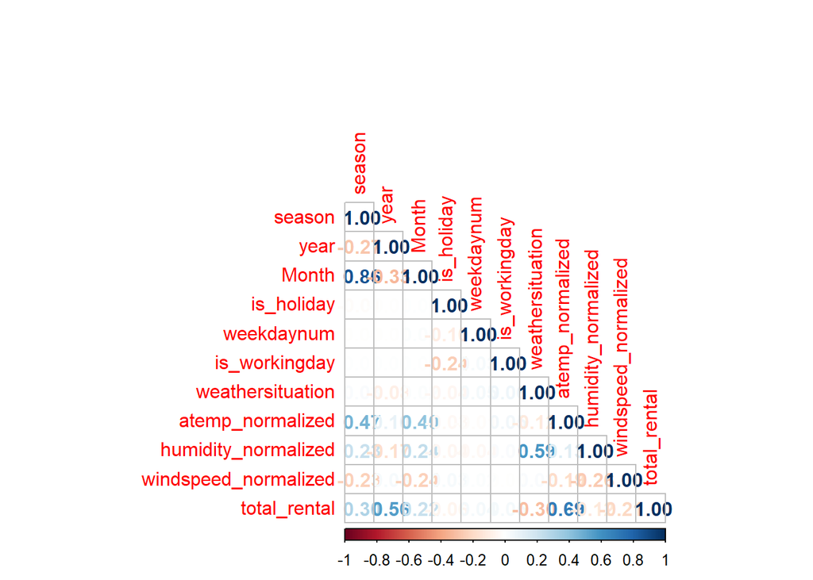

```r
corrmat <- cor(train2)
library(corrplot)
corrplot(corrmat, method='number', type='lower')
```

```r
regression <- step(lm(total_rental~.+Month*season, data=train2), direction='both')
```

```
## Start:  AIC=8006.87
## total_rental ~ season + year + Month + is_holiday + weekdaynum +
##     is_workingday + weathersituation + atemp_normalized + humidity_normalized +
##     windspeed_normalized + Month * season
##
##                        Df Sum of Sq       RSS    AIC
## - is_workingday         1   1185120 368693883 8006.8
## <none>                              367508764 8006.9
## - is_holiday            1   1784748 369293511 8007.8
## - humidity_normalized   1   4674773 372183537 8012.4
## - weekdaynum            1   5528283 373037047 8013.8
## - windspeed_normalized  1  16590088 384098851 8031.3
## - season:Month          1  17226659 384735422 8032.3
## - weathersituation      1  31665457 399174221 8054.4
## - atemp_normalized      1  94956923 462465686 8142.5
## - year                  1 493402107 860910870 8514.8
##
## Step:  AIC=8006.8
## total_rental ~ season + year + Month + is_holiday + weekdaynum +
##     weathersituation + atemp_normalized + humidity_normalized +
##     windspeed_normalized + season:Month
##
##                        Df Sum of Sq       RSS    AIC
## <none>                              368693883 8006.8
## + is_workingday         1   1185120 367508764 8006.9
## - is_holiday            1   2709972 371403855 8009.2
## - humidity_normalized   1   4813416 373507299 8012.6
## - weekdaynum            1   5557591 374251474 8013.8
## - windspeed_normalized  1  16565569 385259452 8031.1
## - season:Month          1  16945383 385639266 8031.7
## - weathersituation      1  30998548 399692431 8053.2
## - atemp_normalized      1  96737206 465431089 8144.4
## - year                  1 492946978 861640861 8513.3
```

```r
summary(regression)
```

```
##
## Call:
## lm(formula = total_rental ~ season + year + Month + is_holiday +
##     weekdaynum + weathersituation + atemp_normalized + humidity_normalized +
##     windspeed_normalized + season:Month, data = train2)
##
## Residuals:
##      Min       1Q   Median       3Q      Max
## -3123.36  -443.86    55.08   487.27  3106.38
##
## Coefficients:
##                      Estimate Std. Error t value Pr(>|t|)
## (Intercept)            931.10     252.40   3.689 0.000246 ***
## season                1052.74     158.27   6.652 6.64e-11 ***
## year                  2061.89      73.54  28.039  < 2e-16 ***
## Month                  164.80      33.17   4.969 8.83e-07 ***
## is_holiday            -420.34     202.19  -2.079 0.038058 *
## weekdaynum              48.61      16.33   2.977 0.003029 **
## weathersituation      -548.04      77.94  -7.031 5.71e-12 ***
## atemp_normalized      4227.25     340.33  12.421  < 2e-16 ***
## humidity_normalized   -843.69     304.51  -2.771 0.005771 **
## windspeed_normalized -2373.48     461.77  -5.140 3.75e-07 ***
## season:Month           -80.21      15.43  -5.199 2.78e-07 ***
## ---
## Signif. codes:  0 '***' 0.001 '**' 0.01 '*' 0.05 '.' 0.1 ' ' 1
##
## Residual standard error: 791.9 on 588 degrees of freedom
## Multiple R-squared:  0.8138, Adjusted R-squared:  0.8106
## F-statistic:   257 on 10 and 588 DF,  p-value: < 2.2e-16
```

```r
library(car)
```

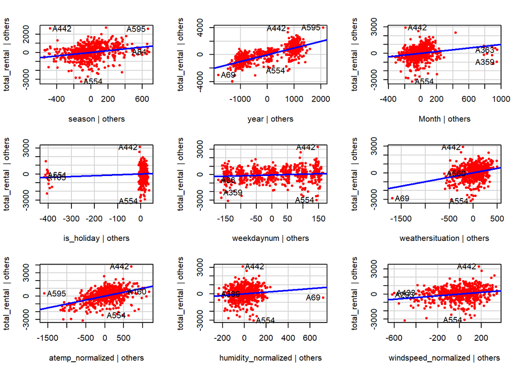

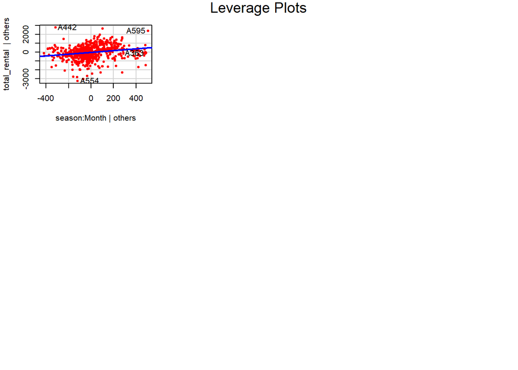

```r
leveragePlots(regression, pch=20, col='red')
```

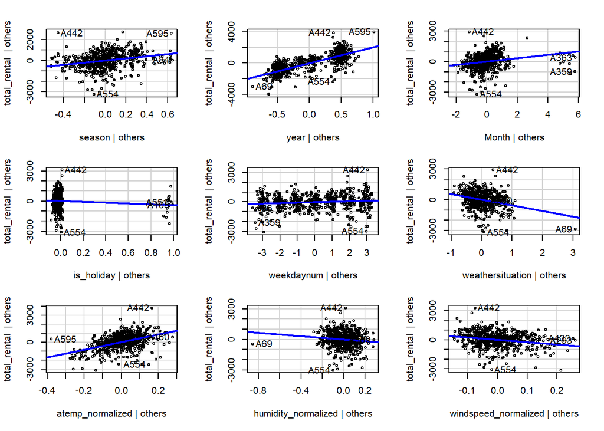

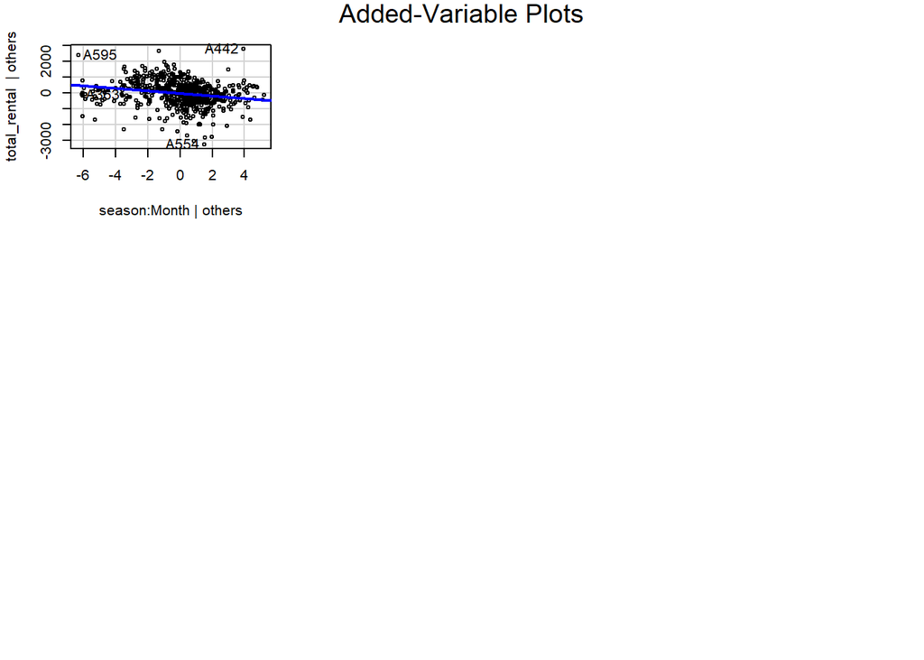

```r
avPlots(regression)
```

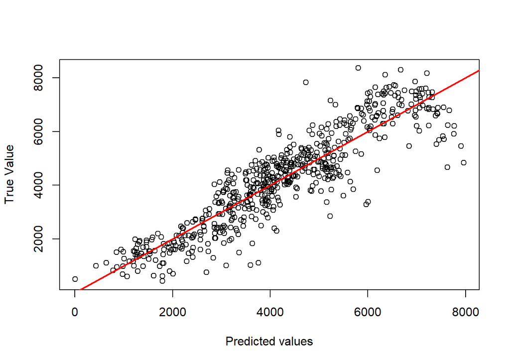

```r
predictregression <- predict(regression, data=train2 ,interval = "confidence")
plot(predictregression[,1], train2$total_rental, xlab='Predicted values', ylab='True Value')
abline(a = 0, b = 1, col = "red",lwd = 2)
```

Thanks to a mixed variables selection approach I detected a multiple regression model with 10 variables and an adjusted R-squared index of 0.81. By analyzing the residual plots, I can see that A442 is a high leverage point and the predicted values are not so strictly linearly correlated with the true values, so I tryed out the random forest model.

```r
library(randomForest)
```

```
## mtry = 10  OOB error = 386263.1
## Searching left ...
## mtry = 5     OOB error = 360996.2
## 0.06541379 0.05
## mtry = 3     OOB error = 365617.1
## -0.01280045 0.05
## Searching right ...
```

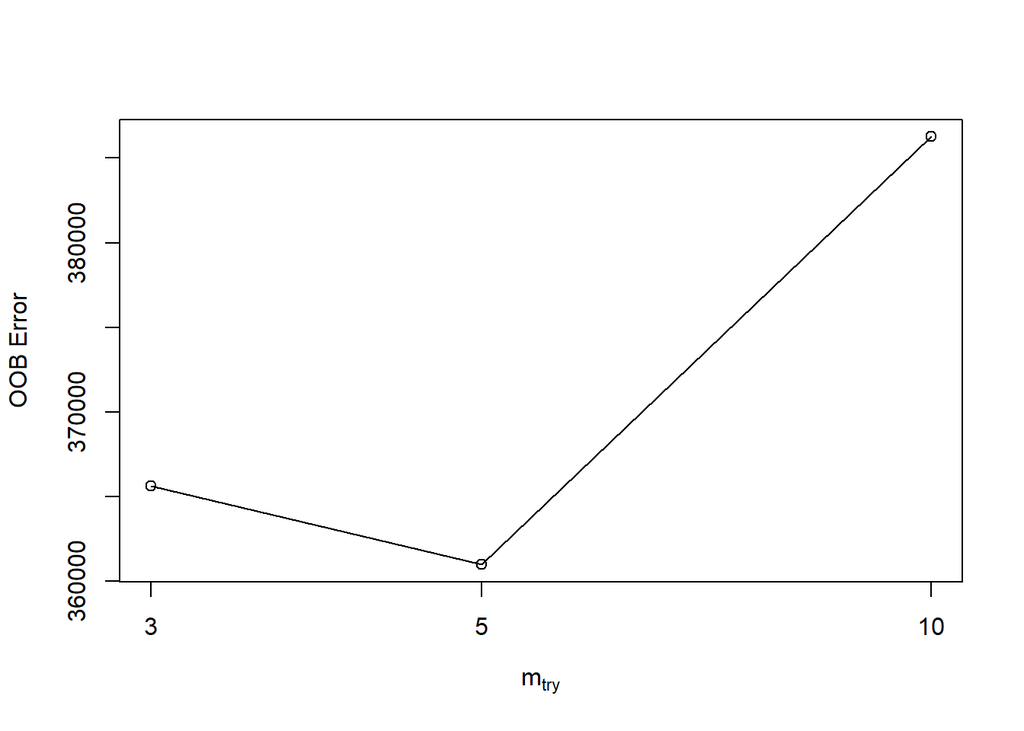

```
##
## Call:
##  randomForest(x = x, y = y, mtry = res[which.min(res[, 2]), 1])
##                Type of random forest: regression
##                      Number of trees: 500
## No. of variables tried at each split: 5
##
##           Mean of squared residuals: 357079.1
##                     % Var explained: 89.2
```

```r
set.seed(1)
(rf <- tuneRF(x = subset(train2, select = -total_rental), y = train$total_rental, ntreeTry =500, plot = TRUE, mtryStart=10, doBest=T))
```

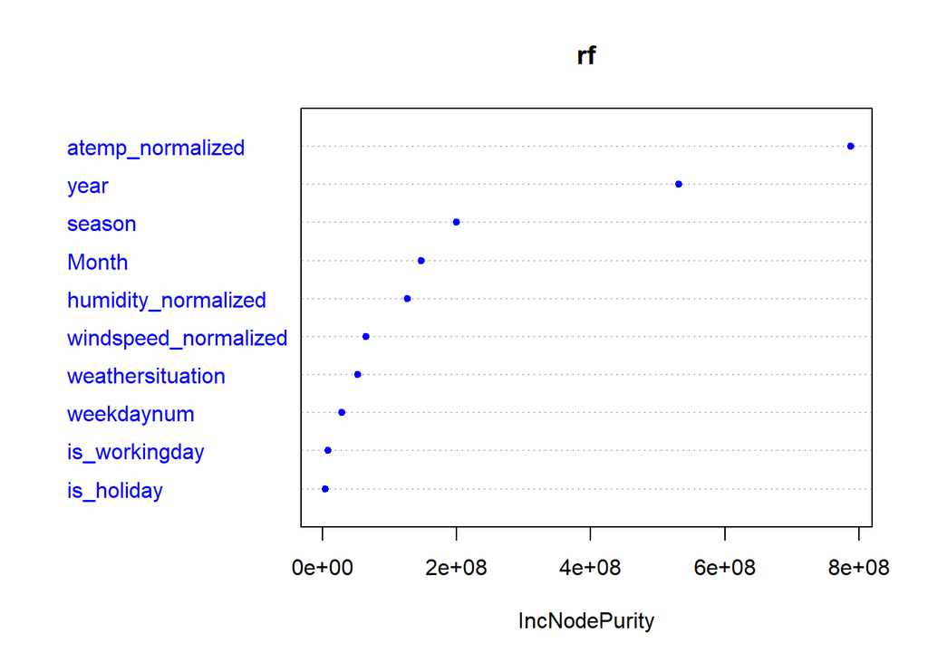

```r
varImpPlot(rf, col="blue", pch=20)
```

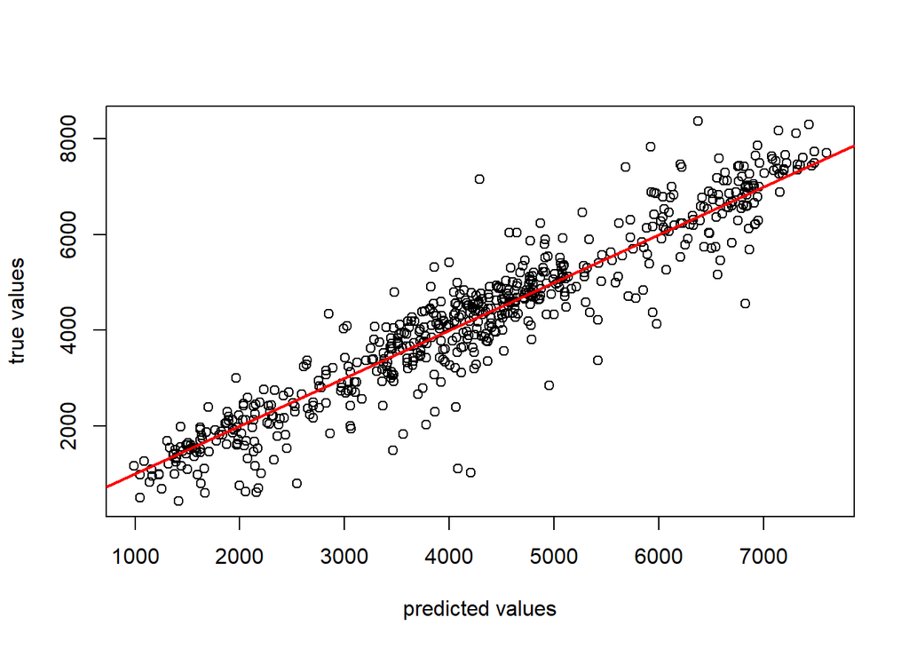

```r
predicttree <- predict(rf, data=train2)
plot(predicttree, train2$total_rental, xlab="predicted values", ylab="true values")
abline(0, 1, col='red', lwd=2)
```

On performing the Random forest model with 500 decision tree and 10 variables, the lowest out-of-bound error was with 5 variables that are temperature, year, season, month and humidity. The predicted values appears to be better correlated to the true values. However, I tried out a xboosting approach.

```r
library(xgboost)
library(caret)
set.seed(1)
parts = createDataPartition(train$total_rental, p = .8, list = F)
dtrain = train[parts, ]
dval = train[-parts, ]

trainx <- data.matrix(dtrain[,2:11])
trainy <- dtrain[,12]

valx <- data.matrix(dval[,2:11])
valy <- dval[,12]

xgb_train <- xgb.DMatrix(data = trainx, label = trainy)
xgb_val = xgb.DMatrix(data = valx, label = valy)

watchlist = list(train=xgb_train, test=xgb_val)
model = xgb.train(data = xgb_train, max.depth = 3, watchlist=watchlist, nrounds = 1000)
```

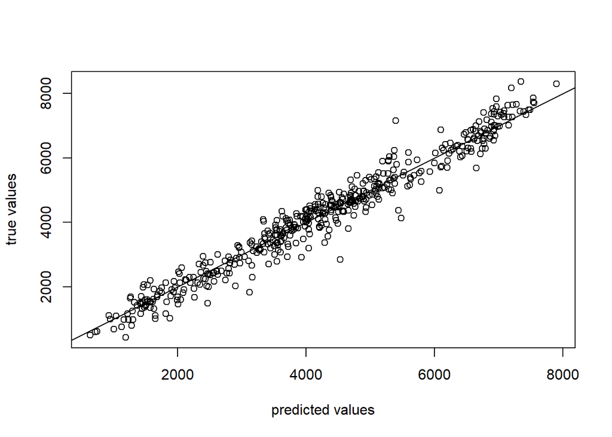

```r
final = xgboost(data = xgb_train, max.depth = 3, nrounds = 41, verbose = 0)

predictboosttrain <- predict(final, newdata=trainx)
predictboostval <- predict(final, newdata=valx)

plot(predictboosttrain, trainy, xlab="predicted values", ylab="true values")
abline(0,1)
```

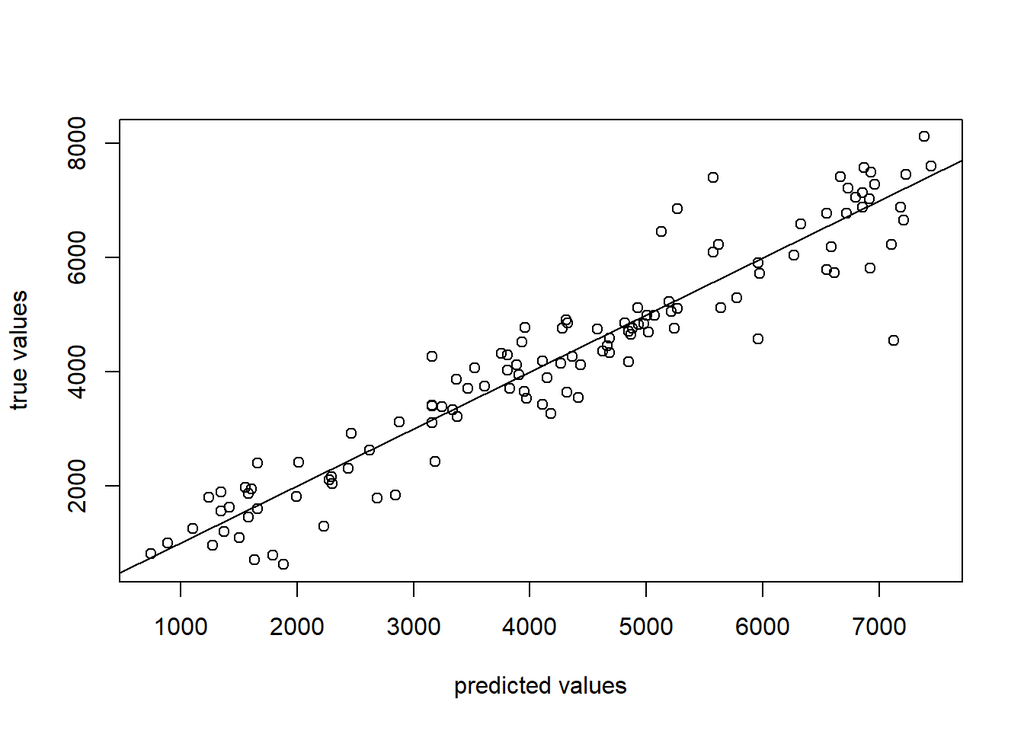

```r
plot(predictboostval, valy, xlab="predicted values", ylab="true values")
abline(0,1)
```

```r
test <- read.csv(file.choose())
rownames(test) <- test$ID
test <- test[,2:12]
test2 <- test[2:11]
testx <- data.matrix(test2[,1:10])
test$total_rental <- predict(final, newdata=testx)
```

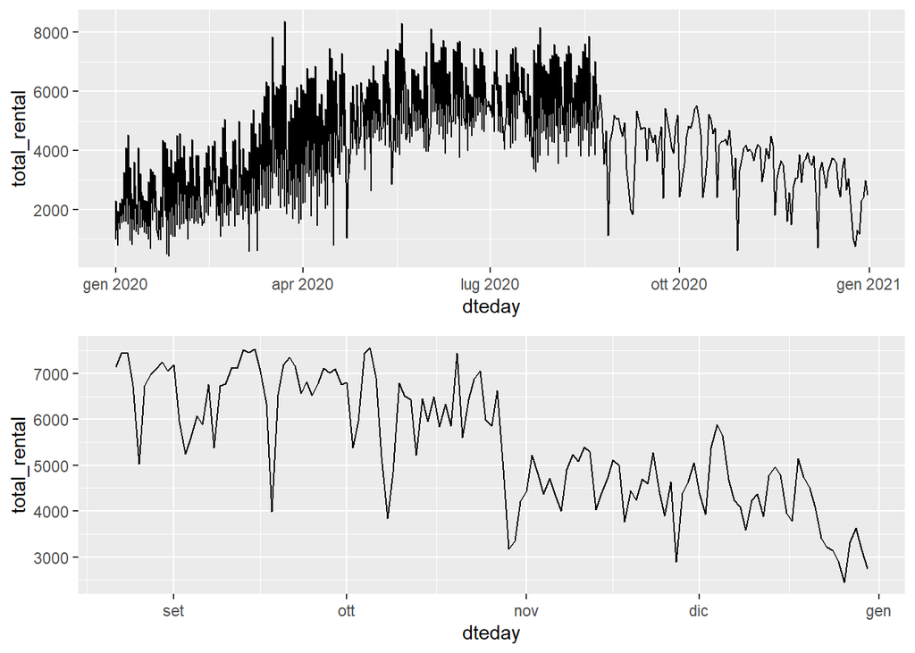

```r
library(ggplot2)
train$dteday <- as.Date(train$dteday, format = "%d-%m-%y")
trainrental <- ggplot(train, aes(x=dteday, y=total_rental)) +geom_line()
test$dteday <- as.Date(test$dteday, format = "%d-%m-%y")
testrental <- ggplot(test, aes(x=dteday, y=total_rental)) +geom_line()
library(gridExtra)
grid.arrange(trainrental, testrental)
```